# Worksheet 14 : Central Limit Theorem

## Today’s Agenda

- More Normal Distribution
- Video
- Central Limit Theorem

## More Normal Distribution

### Review

- The standard normal curve has mean $\mu =0$ and standard deviation $\sigma=1$.
- We denote the standard normal curve $N(0,1)$.
- To find the percentage of data in a region for $N(0,1)$ we use the function `pnorm()`.

For example,

```r
# to find the percentage of data less than -.5 on the standard normal curve we do


# to find the percentage of data greater than 1.7 on the standard normal curve we do


# to find the percentage of data between 1.7 and and -.5 we would do
```

[output not shown]

### Comparing Normal Distributions

Consider the normal distribution $N(1000,200)$ graphed below:

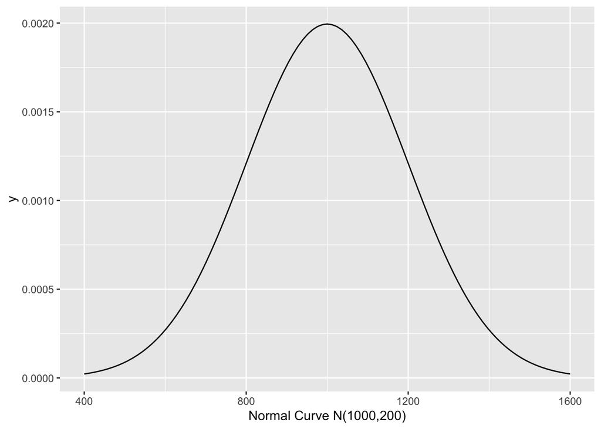

```r
std <- data.frame(axis = seq(400,1600,10))
ggplot(std,aes(x=axis))+ stat_function(fun=dnorm, args = c(1000,200)) + labs(x="Normal Curve N(1000,200)")
```

Assuming perfectly normally distributed data, answer the following questions

1. What percentage of data is less than $800$?
2. What percentage of data is greater than $1200$?
3. What percentage of data is between $1200$ and $800$?
4. What percentage of data is between $1400$ and $600$?
5. What percentage of data is between $1600$ and $400$?

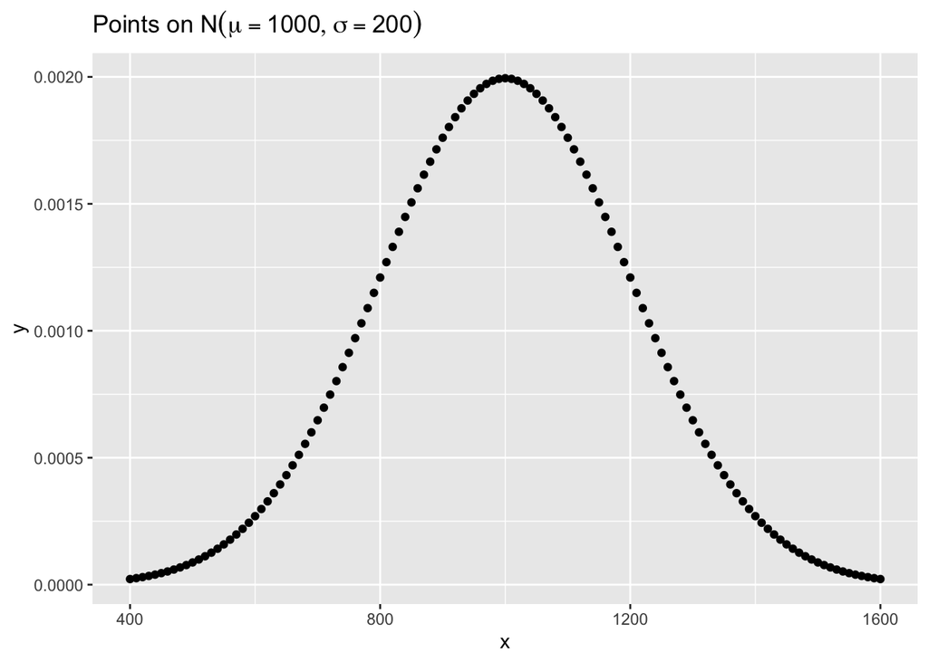

```r
# Below are some points on the curve N(1000,200)

x <- seq(400,1600,10)
y <- dnorm(x,1000,200)
std_1000_200 <- data.frame(x,y)
ggplot(std_1000_200,aes(x=x, y=y))+ geom_point() + labs(title= expression(paste("Points on ", N(mu == 1000, sigma == 200))))
```

```r
# let's convert all of the points to their Z-scores and graph that
```

[output not shown]

### Other norm functions

- `pnorm(x,mu,sigma)` finds the **p**ercentage of data less than $x$ on a normal curve $N(\mu,\sigma)$
- `rnorm(x,mu,sigma)` produces $x$ many **r**andom data points from the curve $N(\mu,\sigma)$
- `dnorm(x,mu,sigma)` tells you the **d**ensity of the data point $x$ on the curve $N(\mu,\sigma)$
- `qnorm(x,mu,sigma)` outputs the data point at the $x$th **q**uantile on the curve $N(\mu,\sigma)$

## Central Limit Theorem

### Video

https://www.youtube.com/watch?v=zeJD6dqJ5lo

6. Given a normal distributed population with mean $5$ and standard deviation $1.2$, what is the $80$th percentile?

```r
# insert code here
```

7. Given a normal distributed population with mean $5$ and standard deviation $1.2$, find the interquartile range.

```r
# insert code here
```

8. Given a normal distributed population with mean $5$ and standard deviation $1.2$, give a range of values that contains $95 \%$ of the population.

```r
# insert code here
```

9. Produce $100$ random normally distributed points on the curve $N(15,3)$?
10. What percentage of data is between $.5$ and $1.25$ on the standard normal curve?